# Take Home Exercise-1

Visual insights reveal the demographic of the city of Engagement, Ohio USA for vast 2022 challenge.

Shachi Anirudha Raodeo https://github.com/ShachiR/ISSS608 (School of Computing and Information Systems)  
2022-04-24

## The Task

This take-home exercise aims to reveal the demographic of the city of Engagement, Ohio USA by using visualization techniques in R.

## Step-by-step Data Visualisation

### Installing and launching R packages

Packages, namely `tidyverse` and `ggplot2` are required for this makeover exercise. This code chunk installs the required packages and loads them onto RStudio environment.

```r
packages = c('tidyverse','ggplot2')
for (p in packages){
  if(!require(p, character.only = T)){
    install.packages(p)
  }
  library(p, character.only = T)
}
```

## Data Preparation

### Data Source

The dataset used in this exercise is Participants.csv, published by the IEEE for [VAST challenge 2022] (https://vast-challenge.github.io/2022/)

### Importing the dataset

The code chunk below imports *Participants.scv* from the data folder into R by using [`read_csv()`](https://readr.tidyverse.org/reference/read_delim.html) function of **readr** and saves it as Tibble data frame called *participants_data*

```r
participants_data <- read_csv("data/Participants.csv")
str(participants_data)
```

```
spec_tbl_df [1,011 x 7] (S3: spec_tbl_df/tbl_df/tbl/data.frame)
 $ participantId : num [1:1011] 0 1 2 3 4 5 6 7 8 9 ...
 $ householdSize : num [1:1011] 3 3 3 3 3 3 3 3 3 3 ...
 $ haveKids      : logi [1:1011] TRUE TRUE TRUE TRUE TRUE TRUE ...
 $ age           : num [1:1011] 36 25 35 21 43 32 26 27 20 35 ...
 $ educationLevel: chr [1:1011] "HighSchoolOrCollege" "HighSchoolOrCollege" "HighSchoolOrCollege" "HighSchoolOrCollege" ...
 $ interestGroup : chr [1:1011] "H" "B" "A" "I" ...
 $ joviality     : num [1:1011] 0.00163 0.32809 0.39347 0.13806 0.8574 ...
 - attr(*, "spec")=
  .. cols(
  ..   participantId = col_double(),
  ..   householdSize = col_double(),
  ..   haveKids = col_logical(),
  ..   age = col_double(),
  ..   educationLevel = col_character(),
  ..   interestGroup = col_character(),
  ..   joviality = col_double()
  .. )
 - attr(*, "problems")=<externalptr>
```

### Data Description

Contains information about the residents Ohio, USA that have agreed to participate in this study.

- *participantId (integer)*: unique ID assigned to each participant
- *householdSize (integer)*: the number of people in the participant’s household
- *haveKids (boolean)*: whether there are children living in the participant’s household
- *age (integer)*: participant’s age in years at the start of the study
- *educationLevel (string factor)*: the participant’s education level, one of: {“Low”, “HighSchoolOrCollege”, “Bachelors”, “Graduate”}
- *interestGroup (char)*: a char representing the participant’s stated primary interest group, one of {“A”, “B”, “C”, “D”, “E”, “F”, “G”, “H”, “I”, “J”}
- *joviality (float)*: a value ranging from [0,1] indicating the participant’s overall happiness level at the start of the study.

### Missing value check

Before we proceed with data visualization we check if the dataset has any null values using the code below.

```r
apply(participants_data, 2, function(x) any(is.na(x)))
```

```
 participantId  householdSize       haveKids            age
         FALSE          FALSE          FALSE          FALSE
educationLevel  interestGroup      joviality
         FALSE          FALSE          FALSE
```

Since there are no null values observed we proceed with our next step.

## Data Wrangling

Display the various age groups present in the dataset using the code below to get an overview of the target age groups in the dataset

```r
participants_data$age <- as.factor(participants_data$age)
levels(participants_data$age)
```

```
 [1] "18" "19" "20" "21" "22" "23" "24" "25" "26" "27" "28" "29" "30"
[14] "31" "32" "33" "34" "35" "36" "37" "38" "39" "40" "41" "42" "43"
[27] "44" "45" "46" "47" "48" "49" "50" "51" "52" "53" "54" "55" "56"
[40] "57" "58" "59" "60"
```

### Grouping age into categories

Since the number of age groups are too many to derive a generalized conclusion we group the ages into five categories - less than or equal to 20, in 20’s, 30’s, 40’s and the ones greater than 50 .

```r
one <- c("18", "19", "20")
two <- c("21", "22", "23", "24", "25", "26", "27", "28", "29", "30" )
three <- c("31", "32", "33", "34", "35", "36", "37", "38", "39", "40")
four <- c( "41", "42", "43", "44", "45", "46", "47", "48", "49", "50")
five <-  c( "51", "52", "53", "54", "55", "56", "57", "58", "59", "60")


participants_data_mod <- participants_data %>%
  mutate(age_modified = case_when(
    age %in% one ~ "<=20",
    age %in% two ~ "20's",
    age %in% three ~ "30's",
    age %in% four ~ "40's",
    age %in% five ~ "50+")) %>%
  select(-age)

head(participants_data_mod)
```

```
# A tibble: 6 x 7
  participantId householdSize haveKids educationLevel    interestGroup
          <dbl>         <dbl> <lgl>    <chr>             <chr>
1             0             3 TRUE     HighSchoolOrColl~ H
2             1             3 TRUE     HighSchoolOrColl~ B
3             2             3 TRUE     HighSchoolOrColl~ A
4             3             3 TRUE     HighSchoolOrColl~ I
5             4             3 TRUE     Bachelors         H
6             5             3 TRUE     HighSchoolOrColl~ D
# ... with 2 more variables: joviality <dbl>, age_modified <chr>
```

### Data Summary

```r
summary(participants_data_mod)
```

```
 participantId    householdSize    haveKids       educationLevel
 Min.   :   0.0   Min.   :1.000   Mode :logical   Length:1011
 1st Qu.: 252.5   1st Qu.:1.000   FALSE:710       Class :character
 Median : 505.0   Median :2.000   TRUE :301       Mode  :character
 Mean   : 505.0   Mean   :1.964
 3rd Qu.: 757.5   3rd Qu.:3.000
 Max.   :1010.0   Max.   :3.000
 interestGroup        joviality        age_modified
 Length:1011        Min.   :0.000204   Length:1011
 Class :character   1st Qu.:0.240074   Class :character
 Mode  :character   Median :0.477539   Mode  :character
                    Mean   :0.493794
                    3rd Qu.:0.746819
                    Max.   :0.999234
```

### Group by

```r
participants_data_new <- summarise_at(group_by(participants_data_mod,age_modified,educationLevel),vars(joviality),funs(mean(.,na.rm=TRUE)))

head(participants_data_new)
```

```
# A tibble: 6 x 3
# Groups:   age_modified [2]
  age_modified educationLevel      joviality
  <chr>        <chr>                   <dbl>
1 <=20         Bachelors               0.444
2 <=20         Graduate                0.583
3 <=20         HighSchoolOrCollege     0.483
4 <=20         Low                     0.466
5 20's         Bachelors               0.536
6 20's         Graduate                0.565
```

### Sorting Data

As shown above, the values of the tibble data frame is sorted according to the age.

```r
participants_data_mod[order(participants_data_mod$age_modified), ]
```

```
# A tibble: 1,011 x 7
   participantId householdSize haveKids educationLevel   interestGroup
           <dbl>         <dbl> <lgl>    <chr>            <chr>
 1             8             3 TRUE     Bachelors        G
 2            13             3 TRUE     Bachelors        J
 3            18             3 TRUE     Graduate         I
 4            29             3 TRUE     Low              C
 5            35             3 TRUE     Low              J
 6            53             3 TRUE     Low              H
 7            67             3 TRUE     HighSchoolOrCol~ C
 8            77             2 FALSE    HighSchoolOrCol~ C
 9            88             2 FALSE    HighSchoolOrCol~ A
10            90             2 FALSE    HighSchoolOrCol~ E
# ... with 1,001 more rows, and 2 more variables: joviality <dbl>,
#   age_modified <chr>
```

## Data Visualization and Insights

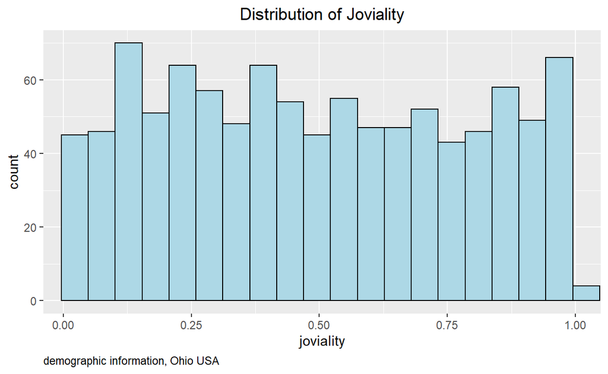

```r
ggplot(data=participants_data,
aes(x = joviality)) +
geom_histogram(bins=20,
boundary = 50,
color="black",
fill="light blue") +
coord_cartesian(xlim=c(0.01,1)) +
labs(
    title = "Distribution of Joviality",
    caption = "demographic information, Ohio USA"
  ) +
  theme(
    plot.title = element_text(hjust = 0.5),
    plot.subtitle = element_text(hjust = 1),
    plot.caption = element_text(hjust = 0)
  )
```

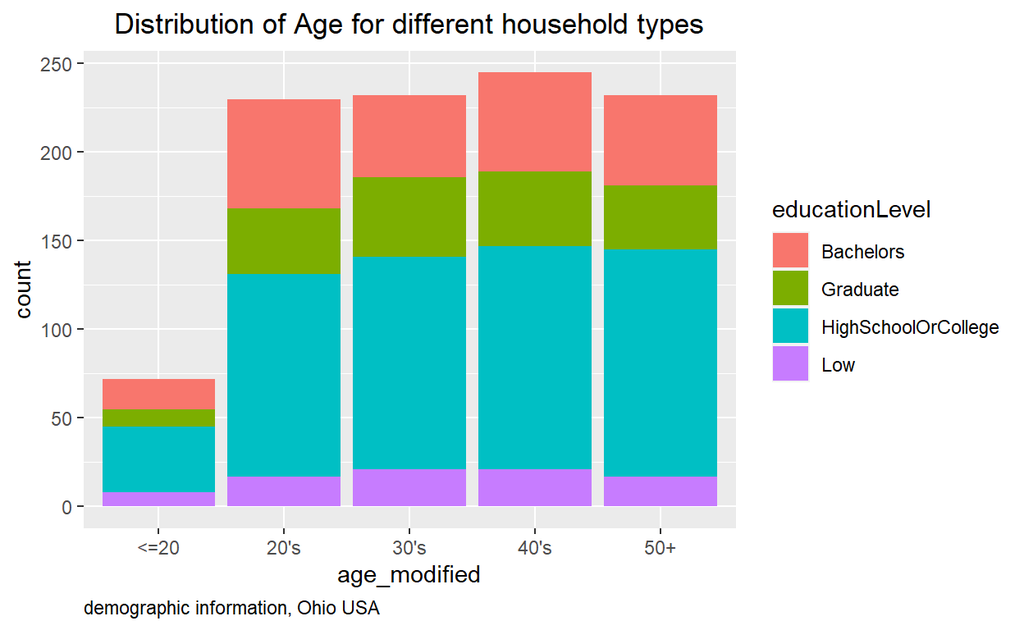

```r
ggplot(data=participants_data_mod,
       aes(x=age_modified, fill = educationLevel)) +
geom_bar()+
labs(
    title = "Distribution of Age for different household types",
    caption = "demographic information, Ohio USA"
  ) +
  theme(
    plot.title = element_text(hjust = 0.5),
    plot.subtitle = element_text(hjust = 1),
    plot.caption = element_text(hjust = 0)
  )
```

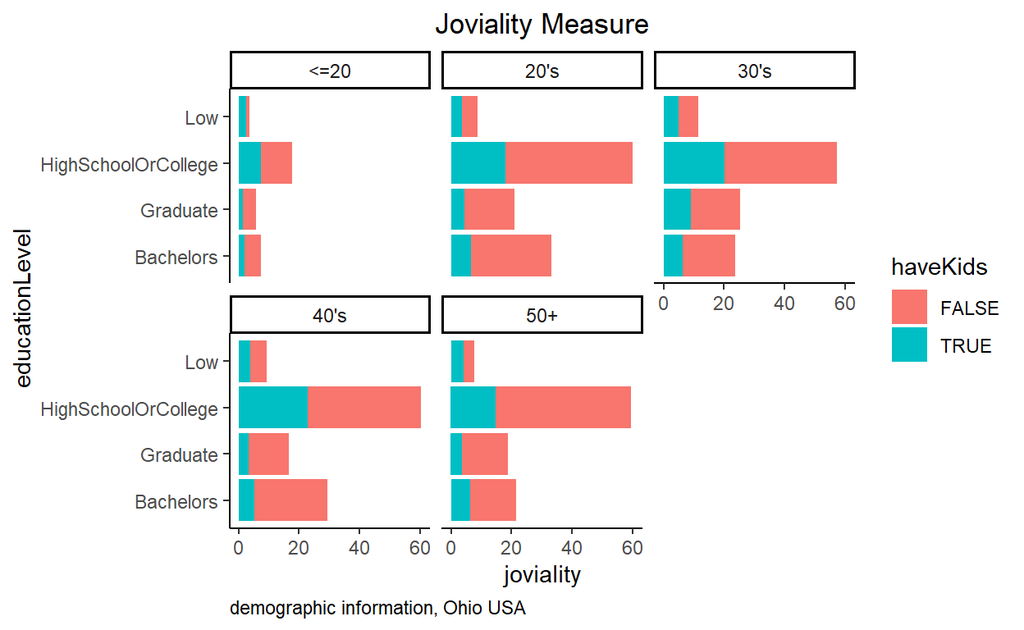

```r
ggplot(data=participants_data_mod,
       aes(x= joviality,
           y= educationLevel, fill = haveKids)) +
     geom_col() +
  theme_classic()+
 labs(
    title = "Joviality Measure",
    caption = "demographic information, Ohio USA"
  ) +
  theme(
    plot.title = element_text(hjust = 0.5),
    plot.subtitle = element_text(hjust = 1),
    plot.caption = element_text(hjust = 0)
  )+
  facet_wrap(~age_modified)
```

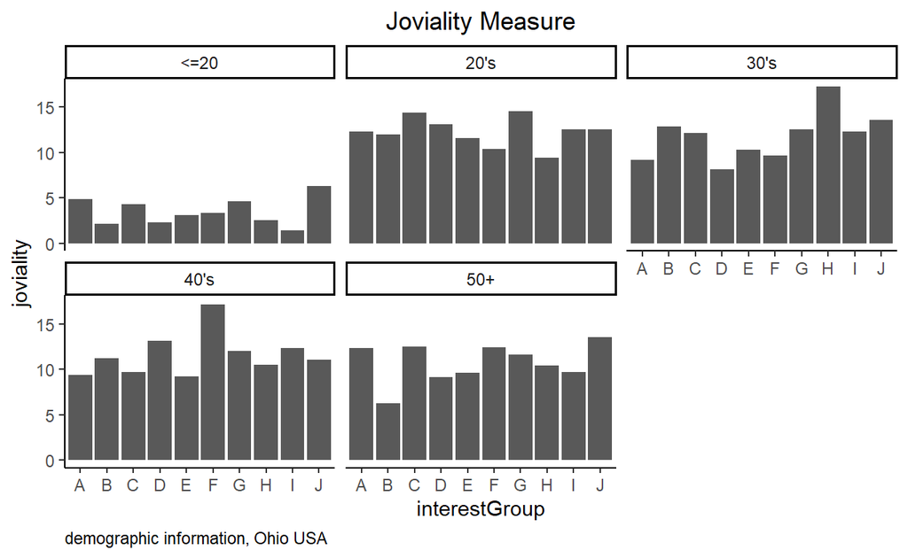

```r
ggplot(data=participants_data_mod,
       aes(x= interestGroup,
           y= joviality)) +
     geom_col() +
  theme_classic()+
 labs(
    title = "Joviality Measure",
    caption = "demographic information, Ohio USA"
  ) +
  theme(
    plot.title = element_text(hjust = 0.5),
    plot.subtitle = element_text(hjust = 1),
    plot.caption = element_text(hjust = 0)
  )+
  facet_wrap(~age_modified)
```